# Understanding Standard Error

# TL;DR

If you have a sample mean of x and a sample error of y you can make a statement like *There is a 68% chance that the population mean is between x-y and x+y.* Send feedback to @bfist on Twitter.

# So what’s up?

Johns Hopkins University is offering a data science certificate through Coursera right now and the course work is really great. However some people have been struggling with the idea of standard error and what that tells us about a population. Well sometimes the best thing is to just have someone else describe it differently in their own words and see if that clicks for you. So I’m going to try to explain standard error for you. I hope it helps.

# The Population

The population is what we want to know about. If I tell you that I took a sample of heights from ten people and the average was 1.62 meters you really couldn’t care less about my sample. You want to know if you can use that sample to estimate the height of everyone. That’s your population. So let’s create a fake population. In my fake world there are only 10,000 people, they are all the same gender, and they are all about 171 centimeters tall. The standard deviation of their height is 20 centimeters.

```r
bfist_world <- rnorm(10000, mean=171, sd=20)
bfist_mean <- mean(bfist_world)
```

You, however, do not know this. You would like to know it, but you don’t know it right now. So you come to my planet in your space vessel and you kidnap ten of my people and measure their heights.

```r
kidnap_sample <- sample(bfist_world, 10)
kidnap_mean <- mean(kidnap_sample)
kidnap_sd <- sd(kidnap_sample)
```

Now you have the average of a **sample** of my people and you have the standard deviation of a **sample** from my people. Let’s take a look at what you’ve got. Here is a histogram of the heights of my people and and a line for the mean. I’ve also added a dot to show you the sample mean you collected.

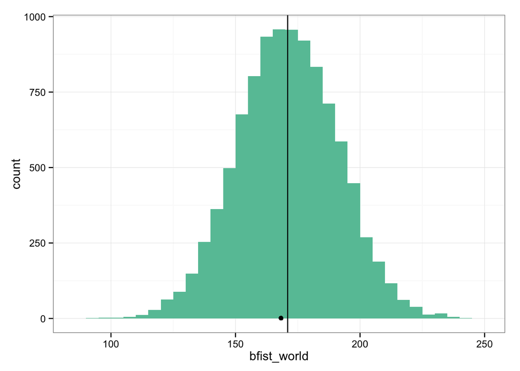

```r
bfist_df <- data.frame(bfist_world)
gg <- ggplot(bfist_df, aes(x=bfist_world)) + geom_histogram(binwidth=5,fill=colors[1])
gg <- gg + theme_bw()
gg <- gg + geom_vline(xintercept=bfist_mean)
gg <- gg + geom_point(x=kidnap_mean, y=1)
print(gg)
```

Hey not bad! You’re really close. But you don’t actually know that. This is where sample error comes into play. You need to figure out how close you are to the real population mean.

# But my mean is really close

Yes it is. This time. You got lucky and pulled a random sample that gave you a really good estimate, but again you don’t know if your estimate is good or not. Let me show what a whole bunch of sample means might look like.

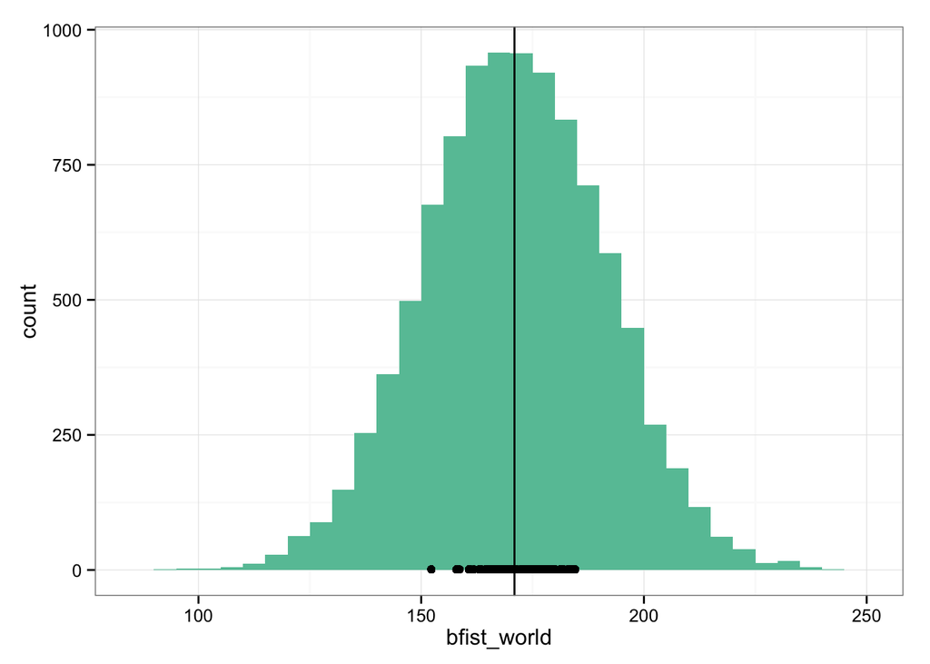

```r
x <- c()
for (i in 1:100) {
  x <- c(x, mean(sample(bfist_world, 10)))
}
y <- rep(1, 100)
far_left_dot <- min(x)
gg <- ggplot(bfist_df, aes(x=bfist_world)) + geom_histogram(binwidth=5,fill=colors[1])
gg <- gg + theme_bw()
gg <- gg + geom_vline(xintercept=bfist_mean)
gg <- gg + geom_point(aes(x=x, y=y))
print(gg)
```

So there is that one dot on the far left just over the 150 centimeter mark. That could have been the mean of your kidnaping sample and you wouldn’t know. Luckily for you if you had really done this one hundred times you would have found that your dots would have started to stack up on each other and make their own histogram and the center of that histogram would be the same center as the population mean. Cool! So now we really just need to know how far our dot might be from the center of that smaller histogram.

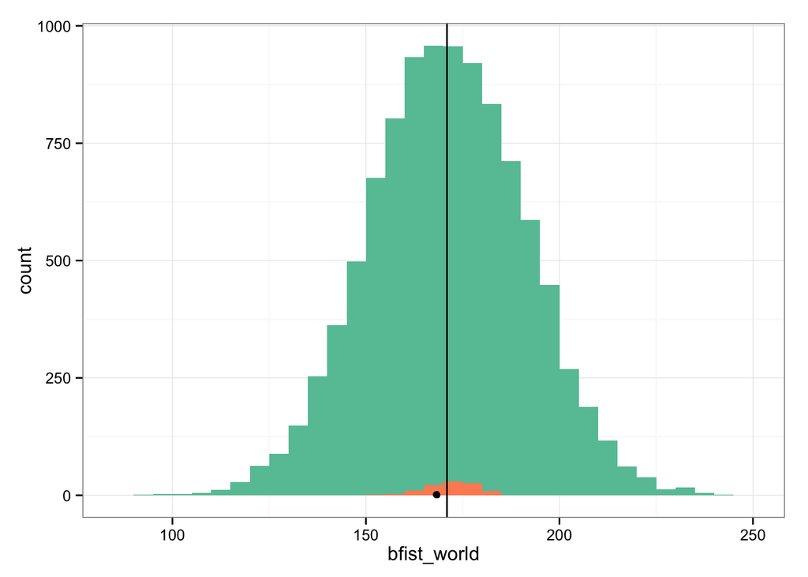

```r
sample_df <- data.frame(x)
gg <- ggplot(bfist_df, aes(x=bfist_world)) + geom_histogram(binwidth=5,fill=colors[1])
gg <- gg + geom_histogram(binwidth=5, data=sample_df, fill=colors[2], aes(x=x))
gg <- gg + theme_bw()
gg <- gg + geom_vline(xintercept=bfist_mean)
gg <- gg + geom_point(aes(x=kidnap_mean, y=y))
print(gg)
```

And that’s what your standard error is measuring. To get your standard error we’re going to take the standard deviation of your kidnapping sample and divide it by the square root of the size of your sample. When you divide by something you make it smaller. When you divide by a small number it gets a little smaller and when you divide by a big number it gets a lot smaller. So you can imagine then that if your sample size was bigger your standard error would be smaller. So small sample size means big standard error. Big sample size means small standard error.

Also remember that in a normal distribution two standard deviations away from the mean covers 95% of your measurements. *I know that isn’t exact. Leave me alone, I’m trying to keep this light.* So if we take our kidnap mean and we add two standard errors we get a top bound. And if we subtract two standard errors we get a bottom bound. And now we can say that there is a 95% chance that the population mean falls between that upper and lower bound. Check this out:

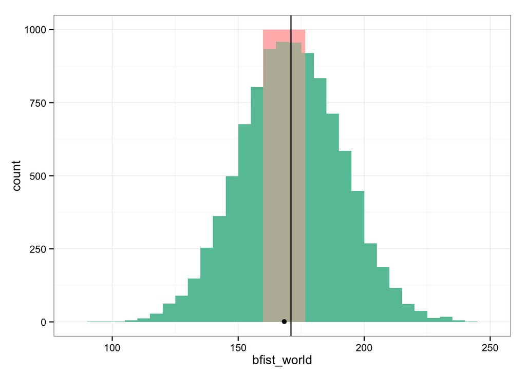

```r
kidnap_er <- kidnap_sd/sqrt(10)
kidnap_low <- kidnap_mean - kidnap_er * 2
kidnap_high <- kidnap_mean + kidnap_er * 2
gg <- ggplot(bfist_df, aes(x=bfist_world)) + geom_histogram(binwidth=5,fill=colors[1])
gg <- gg + geom_rect(aes(xmin=kidnap_low, xmax=kidnap_high, ymin=0, ymax=1000), fill='pink', alpha=0.01)
gg <- gg + theme_bw()
gg <- gg + geom_vline(xintercept=bfist_mean)
gg <- gg + geom_point(aes(x=kidnap_mean, y=y))
print(gg)
```

So what we’re saying is that there is a 95% chance that the true population mean (which you don’t know) falls in the pink shaded area on this graph. And in this case it does. But remember, 95% means that you will be wrong 1 time out of 20. For example, if you had grabbed the sample that resulted in that one extreme mean from earlier and you had the same standard deviation your pink shaded region would look like this:

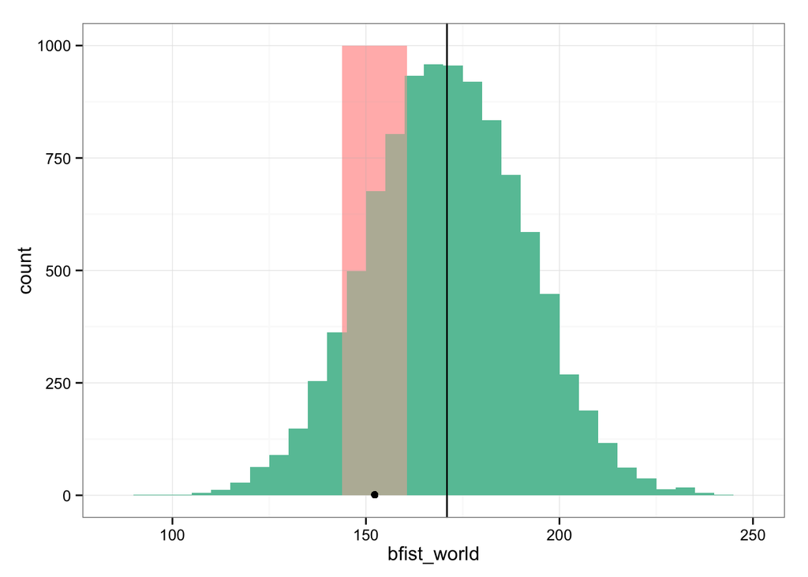

```r
extreme_low <- far_left_dot - kidnap_er * 2
extreme_high <- far_left_dot + kidnap_er * 2
gg <- ggplot(bfist_df, aes(x=bfist_world)) + geom_histogram(binwidth=5,fill=colors[1])
gg <- gg + geom_rect(aes(xmin=extreme_low, xmax=extreme_high, ymin=0, ymax=1000), fill='pink', alpha=0.01)
gg <- gg + theme_bw()
gg <- gg + geom_vline(xintercept=bfist_mean)
gg <- gg + geom_point(aes(x=far_left_dot, y=y))
print(gg)
```

I hope this was helpful. I hope that by presenting it a little bit differently than how it is seen in the lectures it might help to drive it home for you. Give me a shout on Twitter (@bfist) if you have any feedback for me.